title: “Sta 380 HW1” output: html_document —

```r
library(mosaic)
library(foreach)
library(psych)
library(plyr)
```

# Exploratory analysis

```r
georgiaVotes = read.csv('../data/georgia2000.csv', header=TRUE)
summary(georgiaVotes)
```

```
##       county       ballots           votes            equip
##  APPLING :  1   Min.   :   881   Min.   :   832   LEVER  :74
##  ATKINSON:  1   1st Qu.:  3694   1st Qu.:  3506   OPTICAL:66
##  BACON   :  1   Median :  6712   Median :  6299   PAPER  : 2
##  BAKER   :  1   Mean   : 16926   Mean   : 16331   PUNCH  :17
##  BALDWIN :  1   3rd Qu.: 12251   3rd Qu.: 11846
##  BANKS   :  1   Max.   :280975   Max.   :263211
##  (Other) :153
##       poor            urban           atlanta            perAA
##  Min.   :0.0000   Min.   :0.0000   Min.   :0.00000   Min.   :0.0000
##  1st Qu.:0.0000   1st Qu.:0.0000   1st Qu.:0.00000   1st Qu.:0.1115
##  Median :0.0000   Median :0.0000   Median :0.00000   Median :0.2330
##  Mean   :0.4528   Mean   :0.2642   Mean   :0.09434   Mean   :0.2430
##  3rd Qu.:1.0000   3rd Qu.:1.0000   3rd Qu.:0.00000   3rd Qu.:0.3480
##  Max.   :1.0000   Max.   :1.0000   Max.   :1.00000   Max.   :0.7650
##
##       gore             bush
##  Min.   :   249   Min.   :   271
##  1st Qu.:  1386   1st Qu.:  1804
##  Median :  2326   Median :  3597
##  Mean   :  7020   Mean   :  8929
##  3rd Qu.:  4430   3rd Qu.:  7468
##  Max.   :154509   Max.   :140494
##
```

```r
attach(georgiaVotes)
VoteDiscrepancy <- georgiaVotes$votes-georgiaVotes$ballots
georgiaVotes <- data.frame(georgiaVotes,VoteDiscrepancy)
percentDiscrepancy <- abs(georgiaVotes$VoteDiscrepancy/georgiaVotes$ballots)
georgiaVotes <- data.frame(georgiaVotes,percentDiscrepancy)
georgiaVotes$PoorPop=ifelse(georgiaVotes$poor >=1,"Yes","No")
```

## By equipment

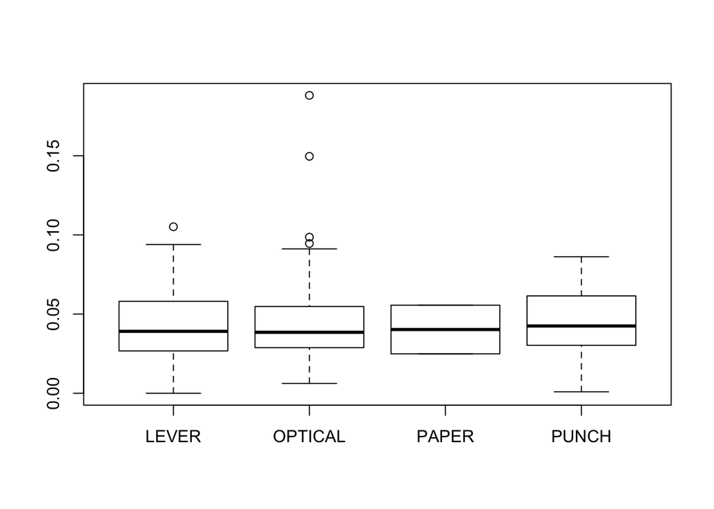

```r
plot(georgiaVotes$equip,georgiaVotes$percentDiscrepancy)
```

- Looking at the graph the median values seem to be around the same by equipment and So I checked the summary statistics to try to confirm this.

```r
lm.GV=lm(percentDiscrepancy ~ equip, data= georgiaVotes)
```

```r
describeBy(georgiaVotes$percentDiscrepancy, georgiaVotes$equip, mat = TRUE)
```

```
##    item  group1 vars  n       mean         sd     median    trimmed
## 11    1   LEVER    1 74 0.04189359 0.02085201 0.03911732 0.04109954
## 12    2 OPTICAL    1 66 0.04517720 0.02987622 0.03851057 0.04096649
## 13    3   PAPER    1  2 0.04024615 0.02173995 0.04024615 0.04024615
## 14    4   PUNCH    1 17 0.04709369 0.02185416 0.04249322 0.04756529
##           mad          min        max      range       skew   kurtosis
## 11 0.01896073 0.0000000000 0.10516881 0.10516881  0.4794795  0.1446663
## 12 0.01812226 0.0062037514 0.18812054 0.18191679  2.3615220  7.8448870
## 13 0.02279121 0.0248736883 0.05561862 0.03074493  0.0000000 -2.7500000
## 14 0.02475318 0.0009149131 0.08619855 0.08528363 -0.1168832 -0.7606385
##             se
## 11 0.002423997
## 12 0.003677508
## 13 0.015372463
## 14 0.005300414
```

- While the medians are all around the same, optical voting equipment seems to have a couple of cases of sizable discrepancy in votes and ballots.

## Poor counties

- The following table illustrates equipment based on whether or not the population has 25% or more of the population 1.5 times below the poverty line.

```r
t1 = xtabs(~ PoorPop + equip, data=georgiaVotes)
t1
```

```
##        equip
## PoorPop LEVER OPTICAL PAPER PUNCH
##     No     29      48     0    10
##     Yes    45      18     2     7
```

- The poor areas had the only two paper voting machines, and roughly 60% of the lever ones. It had just over 25% of the optical machines but had the machines with the two worst voting discrepancies.

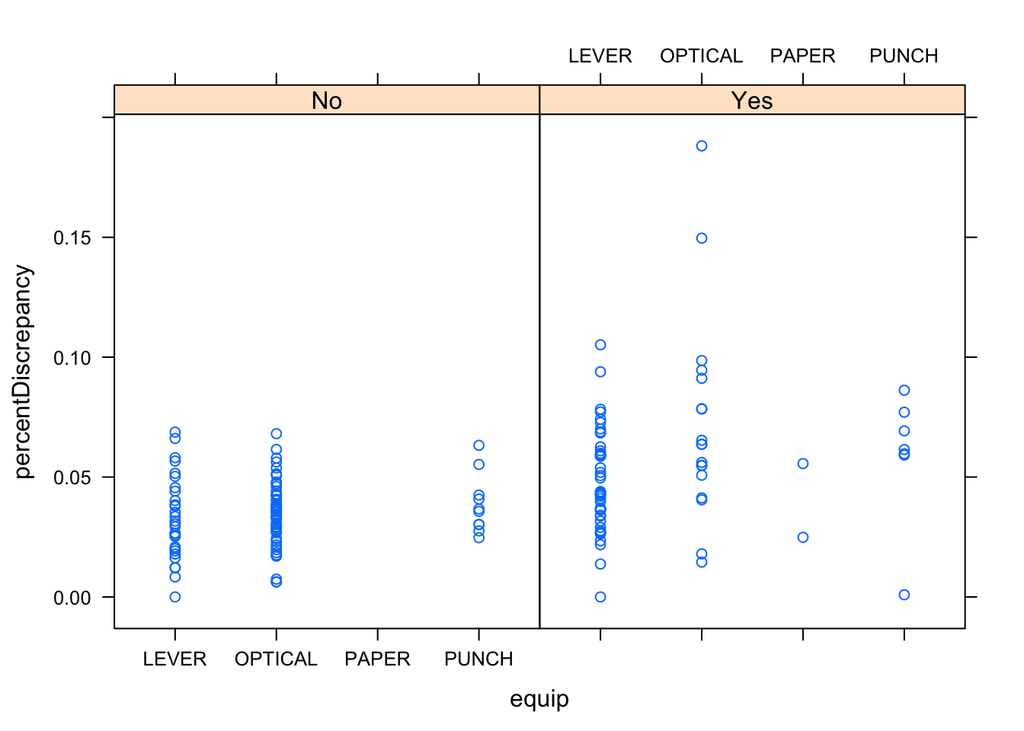

```r
xyplot(percentDiscrepancy ~ equip| PoorPop, data=georgiaVotes)
```

- Grouping the areas and checking out the summary statistics shows that the non poor ares were misvoted by around 3.5 percent on average while the poorer areas were roughly 5.5%. However the standard deviation of the poor areas was nearly 3% so there likely is nothing significant about the findings. Rather than there being a bias with machines, it could just be that the poorer areas are generally less educated so perhaps they didn’t understand the instructions?

```r
describeBy(georgiaVotes$percentDiscrepancy, georgiaVotes$PoorPop, mat = TRUE)
```

```
##    item group1 vars  n       mean         sd     median    trimmed
## 11    1     No    1 87 0.03465805 0.01485018 0.03463353 0.03445011
## 12    2    Yes    1 72 0.05482855 0.02990206 0.05431916 0.05231476
##           mad min        max      range      skew  kurtosis          se
## 11 0.01315181   0 0.06873033 0.06873033 0.1452693 -0.261361 0.001592107
## 12 0.02451786   0 0.18812054 0.18812054 1.5243374  4.784169 0.003523992
```

## Minority Voting discrepancy

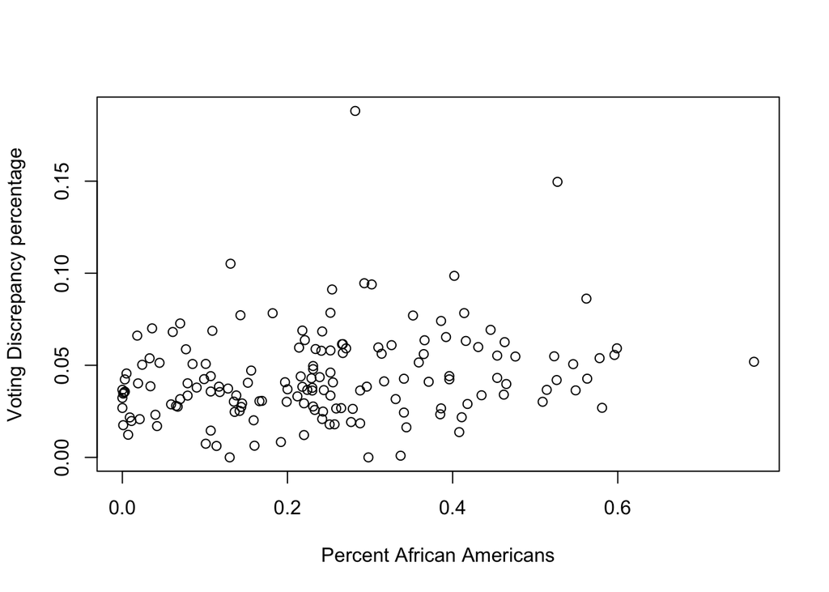

```r
plot(georgiaVotes$perAA,georgiaVotes$percentDiscrepancy,xlab='Percent African Americans',ylab='Voting Discrepancy percentage')
```

-Looking at the graph above, the voting discrepancy numbers seem to be pretty much all over the place. But I wonder how it would break down if sorted by poor areas vs non-poor?

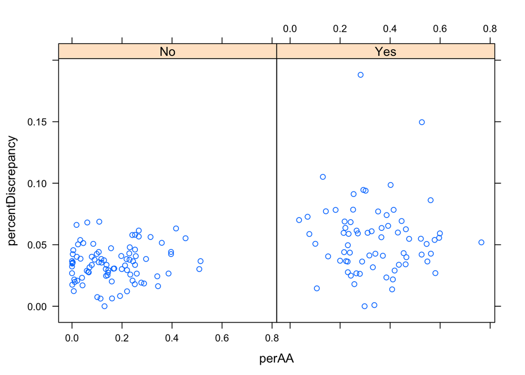

```r
xyplot(percentDiscrepancy ~ perAA| PoorPop, data=georgiaVotes)
```

```r
summary(georgiaVotes$perAA)
```

```
##    Min. 1st Qu.  Median    Mean 3rd Qu.    Max.
##  0.0000  0.1115  0.2330  0.2430  0.3480  0.7650
```

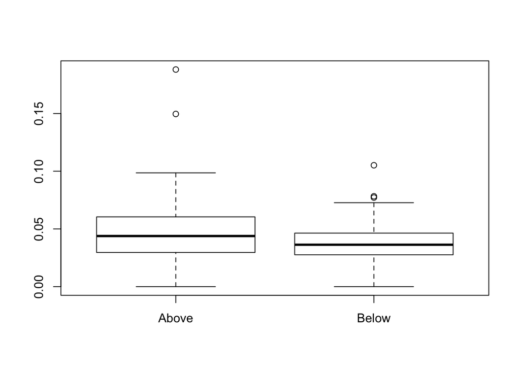

```r
AAMedian <- ifelse(georgiaVotes$perAA >=.2330,"Above","Below")
georgiaVotes <- data.frame(georgiaVotes,AAMedian)
plot(georgiaVotes$AAMedian,georgiaVotes$percentDiscrepancy)
```

- Again it does not look like anything too suspicious is going on here and the statistics of both groups seem to confirm this.

```r
describeBy(georgiaVotes$percentDiscrepancy, georgiaVotes$AAMedian, mat = TRUE)
```

```
##    item group1 vars  n       mean         sd     median    trimmed
## 11    1  Above    1 80 0.04951789 0.02884122 0.04385889 0.04650525
## 12    2  Below    1 79 0.03799335 0.01877141 0.03629595 0.03704242
##           mad min       max     range     skew kurtosis          se
## 11 0.02364149   0 0.1881205 0.1881205 1.850606 6.288717 0.003224546
## 12 0.01321914   0 0.1051688 0.1051688 0.739519 1.084033 0.002111949
```

- However I’ll dig a bit deeper and check out if there is anything odd in the top quartile of African American percentage which is at least .3480.

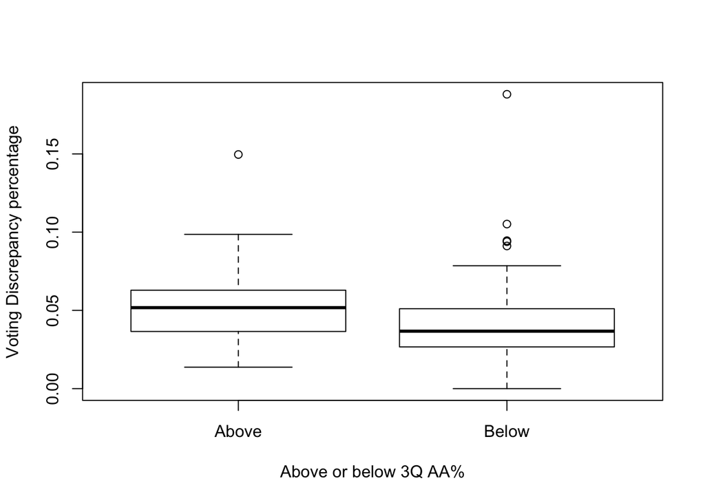

```r
AA3Q <- ifelse(georgiaVotes$perAA >=.3480,"Above","Below")
georgiaVotes <- data.frame(georgiaVotes,AA3Q)
plot(georgiaVotes$AA3Q,georgiaVotes$percentDiscrepancy,xlab='Above or below 3Q AA%',ylab='Voting Discrepancy percentage')
```

- Interestingly enough, the median voter discrepancy is noticebly bigger in the third quartile than the rest of the counties. However the biggest discrepencies actually occurred in the counties with African American populations between the median and third quartile.

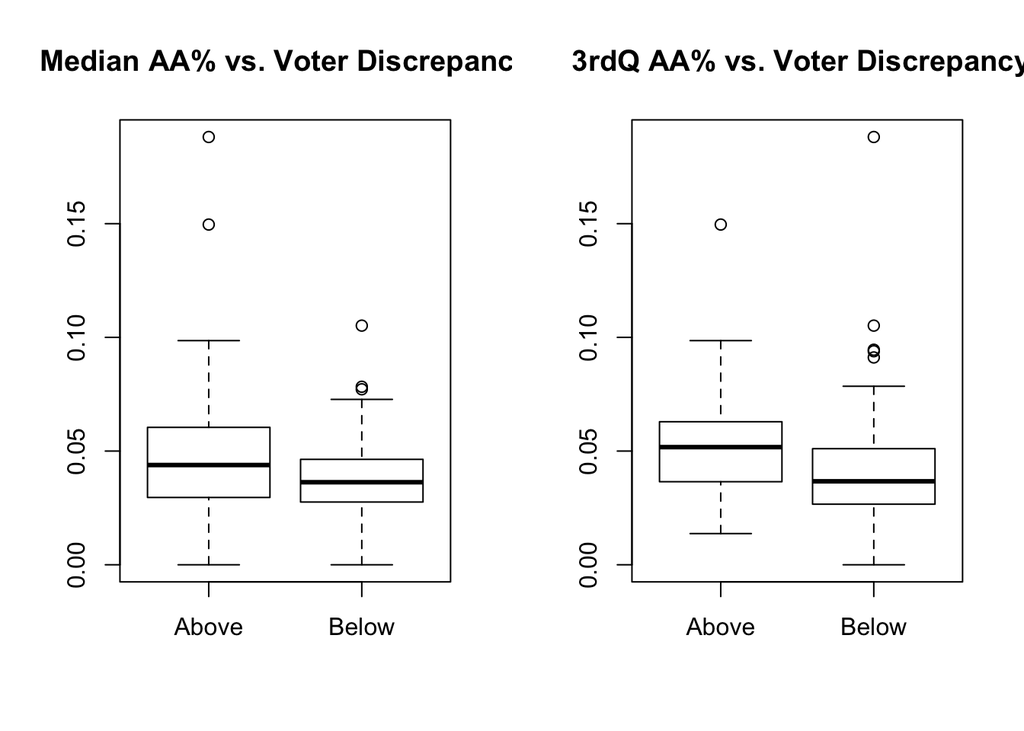

```r
par(mfrow=c(1,2))
plot(georgiaVotes$AAMedian,georgiaVotes$percentDiscrepancy, main = "Median AA% vs. Voter Discrepancy")
plot(georgiaVotes$AA3Q,georgiaVotes$percentDiscrepancy, main= " 3rdQ AA% vs. Voter Discrepancy")
```

```r
describeBy(georgiaVotes$percentDiscrepancy, georgiaVotes$AA3Q, mat = TRUE)
```

```
##    item group1 vars   n       mean         sd     median    trimmed
## 11    1  Above    1  40 0.05248266 0.02427983 0.05173245 0.05003357
## 12    2  Below    1 119 0.04087059 0.02460701 0.03669852 0.03876922
##           mad        min       max     range     skew kurtosis          se
## 11 0.01762105 0.01371308 0.1496193 0.1359063 1.584887 4.320456 0.003838978
## 12 0.01753149 0.00000000 0.1881205 0.1881205 2.078102 9.392758 0.002255721
```

- While again the population below the third quarter is within a standard deviation of the other quarter, it is pretty interesting that the numbers appear to be consistently skewed against the poor and minorities. However it’s hard to say that this is because of a malicious act rather than just a coincidence.

# Boostrapping

```r
library(fImport)
set.seed(10)

myAssets <- c("LQD", "TLT", "SPY","EEM","VNQ")
assetPrices <- yahooSeries(myAssets,from='2010-01-01', to='2015-07-30')

head(assetPrices)
```

```
## GMT
##            LQD.Open LQD.High LQD.Low LQD.Close LQD.Volume LQD.Adj.Close
## 2010-01-04   104.77   104.77  104.34    104.70    2017600      83.95245
## 2010-01-05   104.98   105.45  104.86    105.20    1143800      84.35337
## 2010-01-06   105.39   105.45  104.82    104.89    1005500      84.10480
## 2010-01-07   104.97   105.22  104.87    105.02    1264100      84.20904
## 2010-01-08   105.14   105.25  104.97    105.25     704600      84.39346
## 2010-01-11   105.00   105.38  105.00    105.36     817500      84.48166
##            TLT.Open TLT.High TLT.Low TLT.Close TLT.Volume TLT.Adj.Close
## 2010-01-04    89.84    90.10   89.58     89.81    2829100      75.15839
## 2010-01-05    90.05    90.63   90.00     90.39    2841600      75.64378
## 2010-01-06    90.17    90.26   89.12     89.18    4099600      74.63117
## 2010-01-07    89.22    89.64   89.12     89.33    2793200      74.75670
## 2010-01-08    89.51    89.56   88.76     89.29    2910700      74.72323
## 2010-01-11    88.99    89.36   88.77     88.80    2181300      74.31317
##            SPY.Open SPY.High SPY.Low SPY.Close SPY.Volume SPY.Adj.Close
## 2010-01-04   112.37   113.39  111.51    113.33  118944600      101.4450
## 2010-01-05   113.26   113.68  112.85    113.63  111579900      101.7135
## 2010-01-06   113.52   113.99  113.43    113.71  116074400      101.7852
## 2010-01-07   113.50   114.33  113.18    114.19  131091100      102.2148
## 2010-01-08   113.89   114.62  113.66    114.57  126402800      102.5550
## 2010-01-11   115.08   115.13  114.24    114.73  106375700      102.6982
##            EEM.Open EEM.High EEM.Low EEM.Close EEM.Volume EEM.Adj.Close
## 2010-01-04    42.18    42.74   42.16     42.71   70761600      38.47913
## 2010-01-05    42.91    43.17   42.76     43.02   50196300      38.75843
## 2010-01-06    43.08    43.29   43.01     43.11   50670000      38.83951
## 2010-01-07    42.85    42.98   42.62     42.86   41803700      38.61428
## 2010-01-08    42.88    43.22   42.74     43.20   41118100      38.92060
## 2010-01-11    43.45    43.47   42.90     43.11   42546400      38.83951
##            VNQ.Open VNQ.High VNQ.Low VNQ.Close VNQ.Volume VNQ.Adj.Close
## 2010-01-04    45.22    45.42   44.20     44.55    2408400      36.26420
## 2010-01-05    44.50    44.58   43.93     44.50    2054200      36.22350
## 2010-01-06    44.52    44.84   44.30     44.42    2471200      36.15838
## 2010-01-07    44.46    45.10   43.95     44.90    2091700      36.54911
## 2010-01-08    44.81    44.85   44.18     44.57    2682000      36.28048
## 2010-01-11    44.87    45.06   44.58     44.83    1924800      36.49213
```

```r
summary(assetPrices)
```

```
##     LQD.Open        LQD.High        LQD.Low        LQD.Close
##  Min.   :103.6   Min.   :103.8   Min.   :102.5   Min.   :103.5
##  1st Qu.:111.3   1st Qu.:111.6   1st Qu.:111.0   1st Qu.:111.4
##  Median :115.5   Median :115.7   Median :115.3   Median :115.5
##  Mean   :114.9   Mean   :115.1   Mean   :114.7   Mean   :114.9
##  3rd Qu.:119.2   3rd Qu.:119.4   3rd Qu.:119.0   3rd Qu.:119.1
##  Max.   :123.5   Max.   :123.9   Max.   :123.4   Max.   :123.9
##    LQD.Volume       LQD.Adj.Close       TLT.Open         TLT.High
##  Min.   :  233400   Min.   : 83.32   Min.   : 87.45   Min.   : 87.85
##  1st Qu.:  986650   1st Qu.: 94.86   1st Qu.:101.55   1st Qu.:102.12
##  Median : 1464900   Median :106.52   Median :113.00   Median :113.58
##  Mean   : 1715262   Mean   :104.07   Mean   :110.77   Mean   :111.33
##  3rd Qu.: 2134350   3rd Qu.:111.78   3rd Qu.:119.94   3rd Qu.:120.49
##  Max.   :10863900   Max.   :121.63   Max.   :136.70   Max.   :138.50
##     TLT.Low        TLT.Close        TLT.Volume       TLT.Adj.Close
##  Min.   : 87.3   Min.   : 87.47   Min.   :  987200   Min.   : 73.97
##  1st Qu.:100.8   1st Qu.:101.61   1st Qu.: 5551750   1st Qu.: 87.41
##  Median :112.5   Median :112.95   Median : 7470000   Median :105.90
##  Mean   :110.3   Mean   :110.80   Mean   : 8328027   Mean   :102.54
##  3rd Qu.:119.4   3rd Qu.:119.89   3rd Qu.: 9905200   3rd Qu.:113.52
##  Max.   :136.7   Max.   :138.28   Max.   :46221000   Max.   :136.27
##     SPY.Open        SPY.High        SPY.Low        SPY.Close
##  Min.   :103.1   Min.   :103.4   Min.   :101.1   Min.   :102.2
##  1st Qu.:126.4   1st Qu.:127.2   1st Qu.:125.5   1st Qu.:126.3
##  Median :142.0   Median :142.5   Median :141.4   Median :142.0
##  Mean   :153.7   Mean   :154.5   Mean   :152.9   Mean   :153.7
##  3rd Qu.:185.1   3rd Qu.:186.1   3rd Qu.:184.2   3rd Qu.:185.0
##  Max.   :213.2   Max.   :213.8   Max.   :212.9   Max.   :213.5
##    SPY.Volume        SPY.Adj.Close      EEM.Open        EEM.High
##  Min.   : 42963400   Min.   : 92.3   Min.   :33.93   Min.   :34.94
##  1st Qu.:102991650   1st Qu.:116.5   1st Qu.:39.73   1st Qu.:39.97
##  Median :137701700   Median :134.3   Median :41.62   Median :41.85
##  Mean   :155759761   Mean   :146.4   Mean   :41.92   Mean   :42.16
##  3rd Qu.:186665300   3rd Qu.:180.1   3rd Qu.:43.59   3rd Qu.:43.81
##  Max.   :717828700   Max.   :212.6   Max.   :50.27   Max.   :50.43
##     EEM.Low        EEM.Close       EEM.Volume        EEM.Adj.Close
##  Min.   :33.42   Min.   :34.36   Min.   : 18409100   Min.   :31.74
##  1st Qu.:39.41   1st Qu.:39.72   1st Qu.: 43785700   1st Qu.:37.71
##  Median :41.35   Median :41.61   Median : 55294900   Median :39.67
##  Mean   :41.63   Mean   :41.91   Mean   : 60461582   Mean   :39.57
##  3rd Qu.:43.40   3rd Qu.:43.62   3rd Qu.: 71176850   3rd Qu.:41.63
##  Max.   :49.94   Max.   :50.20   Max.   :225063100   Max.   :45.91
##     VNQ.Open        VNQ.High        VNQ.Low        VNQ.Close
##  Min.   :40.99   Min.   :41.53   Min.   :40.33   Min.   :41.04
##  1st Qu.:56.83   1st Qu.:57.27   1st Qu.:56.08   1st Qu.:56.78
##  Median :65.27   Median :65.68   Median :64.93   Median :65.27
##  Mean   :64.88   Mean   :65.31   Mean   :64.38   Mean   :64.87
##  3rd Qu.:72.29   3rd Qu.:72.58   3rd Qu.:71.84   3rd Qu.:72.33
##  Max.   :88.83   Max.   :89.27   Max.   :88.30   Max.   :88.65
##    VNQ.Volume       VNQ.Adj.Close
##  Min.   :  661100   Min.   :33.41
##  1st Qu.: 1895550   1st Qu.:48.45
##  Median : 2532300   Median :58.86
##  Mean   : 2884511   Mean   :58.91
##  3rd Qu.: 3462450   3rd Qu.:67.93
##  Max.   :11383300   Max.   :87.24
```

```r
AssetPricesToReturns = function(series) {
  mycols = grep('Adj.Close', colnames(series))
  closingprice = series[,mycols]
  N = nrow(closingprice)
  percentreturn = as.data.frame(closingprice[2:N,]) / as.data.frame(closingprice[1:(N-1),]) - 1
  mynames = strsplit(colnames(percentreturn), '.', fixed=TRUE)
  mynames = lapply(mynames, function(x) return(paste0(x[1], ".PctReturn")))
  colnames(percentreturn) = mynames
  as.matrix(na.omit(percentreturn))
}

Assetreturns = AssetPricesToReturns(assetPrices)
n_days=20
```

- In order to properly understand the risk/reward property of each asset I will run bootstrap simulations of 4 trading weeks for each asset.
- I will examine the 5% value at risk to determine the risk of each portfolio as well as look at the histograms to try to get the expected returns.
- With each asset I will invest 10000 and see it’s sampled value after 20 days, the length of the bootstrap test that will ultimately been done on the three portfolios.
- For each asset I will run 100 simulations to get an idea of the possible scenarios then compute the mean to determine expected return as well as standard deviation.

## LQD

```r
LQDSim = foreach(i=1:100, .combine='rbind') %do% {
totalwealth = 10000
weights = c(1, 0.0, 0.0, 0.0, 0.0)
holdings = weights * totalwealth
wealthtracker = rep(0, n_days) # Set up a placeholder to track total wealth
for(today in 1:n_days) {
return.today = resample(Assetreturns, 1, orig.ids=FALSE)
holdings = holdings + holdings*return.today
totalwealth = sum(holdings)
wealthtracker[today] = totalwealth
}
wealthtracker
}

head(LQDSim)
```

```
##               [,1]      [,2]      [,3]      [,4]      [,5]      [,6]
## result.1 10030.985 10086.296 10047.141 10054.248 10071.113 10038.652
## result.2  9966.639  9935.865  9963.694  9932.952  9997.823 10038.225
## result.3  9961.390  9996.430  9985.944 10034.511 10014.636  9932.497
## result.4 10009.465 10032.631 10011.730 10005.604 10012.277  9998.504
## result.5  9994.176  9970.192  9938.045 10013.568 10041.351 10052.970
## result.6 10023.208 10055.726 10091.847 10081.364  9975.981  9999.444
##               [,7]      [,8]      [,9]     [,10]     [,11]     [,12]
## result.1  9976.703 10009.938  9990.991  9992.719  9932.737  9916.202
## result.2 10039.912 10054.483 10059.612 10028.574 10060.905 10066.490
## result.3  9942.009  9976.063  9954.905  9954.066  9911.906  9926.557
## result.4 10011.943 10009.389 10051.370 10018.231 10059.973 10074.297
## result.5 10052.121  9990.088  9897.165  9836.739  9828.588  9813.998
## result.6 10086.441 10065.465 10088.588 10093.773 10084.456 10087.028
##              [,13]     [,14]     [,15]     [,16]     [,17]     [,18]
## result.1  9937.432  9981.665  9976.381 10000.610 10022.318 10048.502
## result.2 10005.030  9972.775  9952.272  9922.396  9932.415  9940.703
## result.3  9939.969  9956.704  9973.229 10003.859 10022.954 10016.258
## result.4  9994.013  9970.301  9934.495  9944.384  9973.566  9964.240
## result.5  9826.895  9796.297  9781.121  9802.272  9814.643  9823.584
## result.6 10082.406 10066.604 10092.268 10060.227 10030.250 10051.503
##              [,19]     [,20]
## result.1 10056.389 10008.550
## result.2  9950.185  9980.988
## result.3 10038.078 10011.085
## result.4  9937.324  9884.345
## result.5  9855.542  9871.411
## result.6 10012.000 10013.745
```

```r
par(mfrow=c(1,2))
```

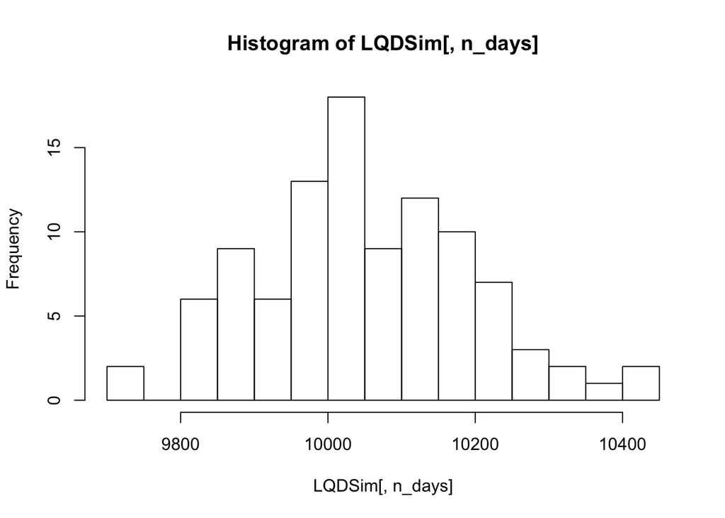

```r
hist(LQDSim[,n_days],25) #This shows the values at the 20th day
```

### Checking for profits

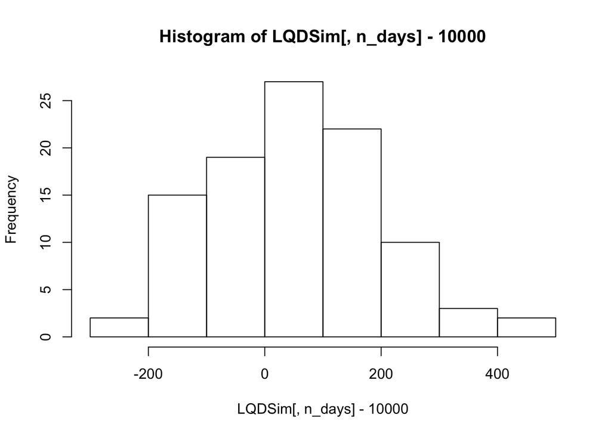

```r
hist(LQDSim[,n_days]- 10000)
```

```r
mean(LQDSim[,n_days])-10000
```

```
## [1] 52.03869
```

```r
(mean(LQDSim[,n_days])-10000)/10000*100
```

```
## [1] 0.5203869
```

- On average the LQD account return is $10,052.04 over 20 days or a return of 0.52%

```r
quantile(LQDSim[,n_days], 0.05) - 10000
```

```
##        5%
## -165.1949
```

- The 5% value at risk is 165.19 dollars.

```r
sd((LQDSim[,n_days])-10000)
```

```
## [1] 146.1562
```

- Meanwhile the standard deviation is $146.15

## TLT

```r
TLTSim = foreach(i=1:100, .combine='rbind') %do% {
totalwealth = 10000
weights = c(0.0, 1.0, 0.0, 0.0, 0.0)
holdings = weights * totalwealth
wealthtracker = rep(0, n_days) # Set up a placeholder to track total wealth
for(today in 1:n_days) {
return.today = resample(Assetreturns, 1, orig.ids=FALSE)
holdings = holdings + holdings*return.today
totalwealth = sum(holdings)
wealthtracker[today] = totalwealth
}
wealthtracker
}
head(TLTSim)
```

```
##               [,1]      [,2]      [,3]      [,4]      [,5]      [,6]
## result.1 10005.947 10116.659 10023.232  9824.421  9830.015  9769.847
## result.2 10088.147 10159.196 10173.818 10165.036 10152.670 10075.459
## result.3 10087.055 10016.242 10083.104  9933.364  9916.270  9991.165
## result.4  9756.754  9805.787  9893.339  9898.809  9941.039  9908.978
## result.5  9915.549  9786.025  9841.904  9678.028  9654.046  9613.981
## result.6 10083.195 10155.710 10293.532 10303.288 10269.496 10230.765
##               [,7]      [,8]      [,9]     [,10]     [,11]     [,12]
## result.1  9794.239  9583.770  9592.785  9646.730  9640.872  9657.088
## result.2 10129.018 10207.426 10077.988 10016.574 10065.980 10022.639
## result.3  9791.499  9657.667  9770.291  9822.407 10171.897 10127.440
## result.4  9934.553  9906.336  9941.700 10043.601  9944.413  9900.674
## result.5  9408.173  9332.807  9342.872  9416.674  9400.943  9281.812
## result.6 10126.113 10051.197 10112.970 10287.806 10214.551 10156.098
##              [,13]     [,14]     [,15]     [,16]     [,17]     [,18]
## result.1  9524.270  9555.554  9513.935  9632.589  9621.700  9639.502
## result.2  9957.874 10037.241  9985.808  9925.075 10128.214  9959.570
## result.3 10118.698  9963.143 10038.724 10030.269  9998.984 10039.527
## result.4  9921.029 10020.915 10103.939 10246.910 10235.322 10337.085
## result.5  9267.039  9331.238  9358.448  9341.794  9394.712  9210.719
## result.6 10113.343  9974.647 10086.801 10196.082 10106.105  9899.875
##              [,19]     [,20]
## result.1  9645.235  9571.111
## result.2  9971.556  9938.561
## result.3 10072.999  9994.449
## result.4 10401.668 10448.145
## result.5  9317.112  9110.001
## result.6 10078.027 10093.779
```

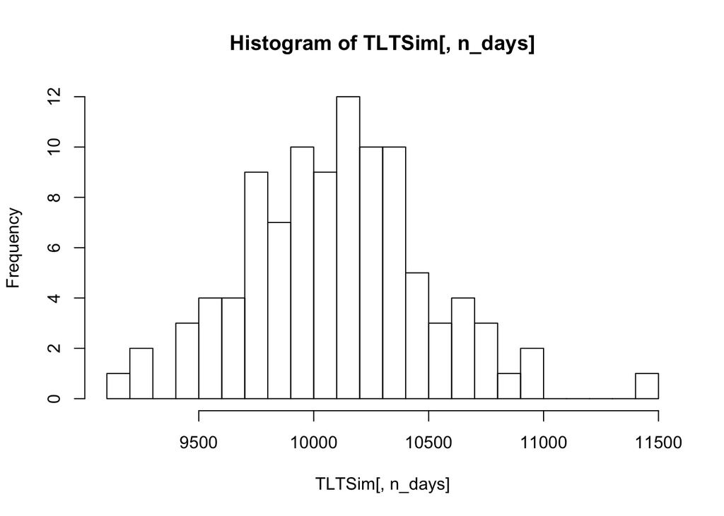

```r
hist(TLTSim[,n_days],25)
```

-It appears the most prevalent TLTSims are between +/- $500 of 10,000.

### Checking for profits

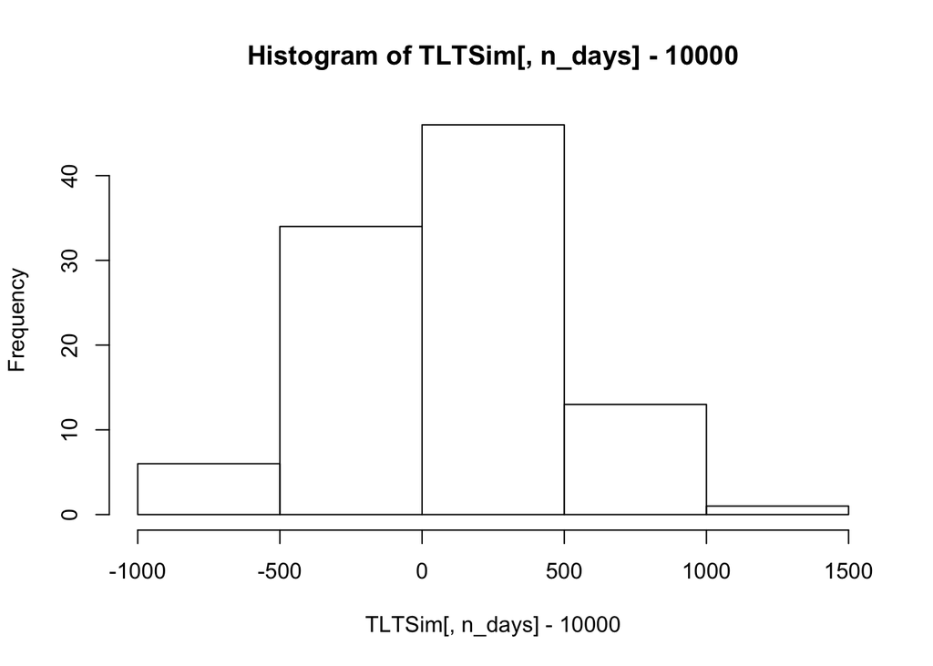

```r
hist(TLTSim[,n_days]- 10000)
```

```r
mean(TLTSim[,n_days])-10000
```

```
## [1] 105.3749
```

```r
(mean(TLTSim[,n_days])-10000)/10000*100
```

```
## [1] 1.053749
```

- The average return is 10,105.37 for a $10,000 investment or 1.05%

### Value at Risk

```r
quantile(TLTSim[,n_days], 0.05) - 10000
```

```
##        5%
## -506.4087
```

- The five percent value at risk is -506.41 dollars.

```r
sd(TLTSim[,n_days], 0.05 - 10000)
```

```
## [1] 404.9961
```

- The standard deviation is $405

## SPY

```r
SPYSim = foreach(i=1:100, .combine='rbind') %do% {
totalwealth = 10000
weights = c(0, 0.0, 1.0, 0.0, 0.0)
holdings = weights * totalwealth
wealthtracker = rep(0, n_days) # Set up a placeholder to track total wealth
for(today in 1:n_days) {
return.today = resample(Assetreturns, 1, orig.ids=FALSE)
holdings = holdings + holdings*return.today
totalwealth = sum(holdings)
wealthtracker[today] = totalwealth
}
wealthtracker
}

head(SPYSim)
```

```
##               [,1]      [,2]      [,3]      [,4]      [,5]      [,6]
## result.1 10074.427  9720.443  9721.476  9828.305  9786.508  9870.322
## result.2 10063.162 10178.794 10304.968 10139.765 10209.603 10120.090
## result.3 10049.343 10215.131  9856.204  9905.509  9895.031  9908.094
## result.4  9853.462  9862.677  9779.372  9815.823  9873.142  9967.688
## result.5 10050.258 10051.952 10016.957 10024.933 10065.120 10071.499
## result.6  9993.375  9999.909  9928.067  9708.998  9749.238  9791.725
##               [,7]      [,8]      [,9]     [,10]     [,11]     [,12]
## result.1  9932.902  9946.245  9942.087  9781.667  9877.195  9930.001
## result.2 10146.903 10074.750 10015.728 10000.165 10440.582 10465.780
## result.3  9979.638  9981.320 10141.109 10069.796 10166.097 10052.103
## result.4  9921.870  9915.054  9908.335 10054.610  9929.623 10076.344
## result.5 10242.134 10251.039 10402.509 10448.860 10496.086 10504.252
## result.6  9848.563  9892.003 10026.850 10084.449  9855.898  9918.142
##              [,13]     [,14]     [,15]     [,16]    [,17]     [,18]
## result.1  9875.886  9847.602  9963.334  9985.311 10020.70 10076.280
## result.2 10469.737 10387.540 10366.621 10374.875 10446.73 10518.472
## result.3 10191.538 10048.847 10091.696 10122.461 10200.62 10191.644
## result.4 10102.208 10122.849 10147.137 10486.516 10551.74 10560.460
## result.5 10566.114 10550.138 10652.186 10693.032 10756.41 10828.681
## result.6  9880.375  9983.900 10027.340 10078.318 10100.40  9974.847
##             [,19]    [,20]
## result.1 10078.67 10062.49
## result.2 10514.49 10368.23
## result.3 10172.41 10314.68
## result.4 10517.19 10417.55
## result.5 10648.23 10515.86
## result.6 10024.98 10082.57
```

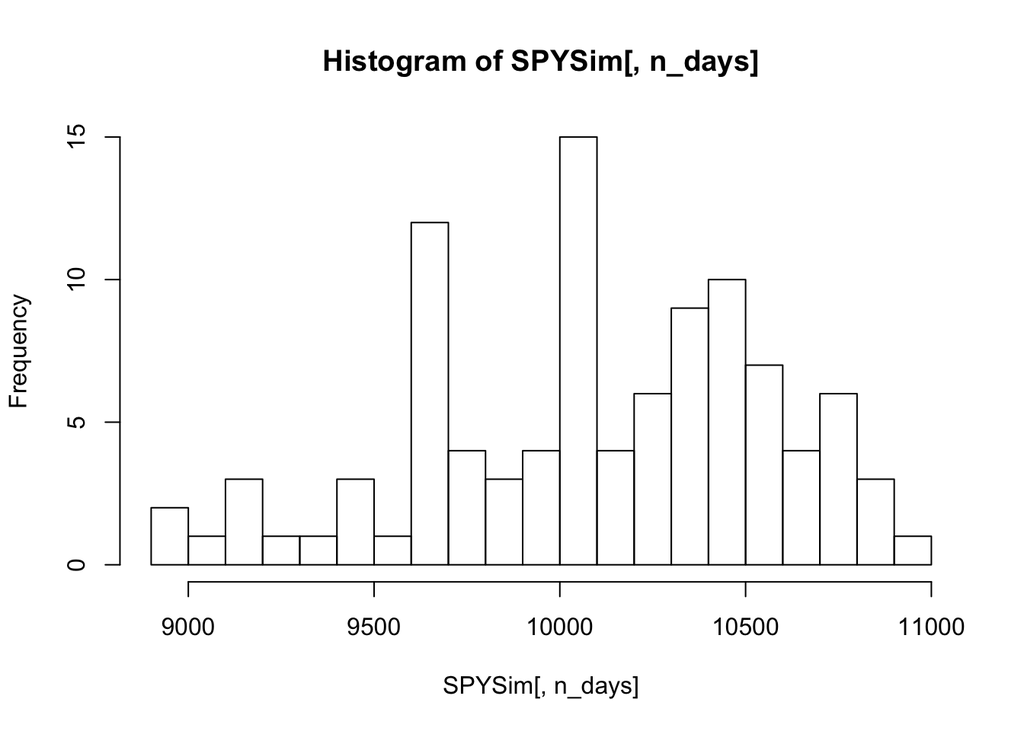

```r
hist(SPYSim[,n_days],25)
```

- It appears the most prevalent SPYSims are between +/- $500 of 10,000.Though in some cases it’s more around $600

### Checking for profits

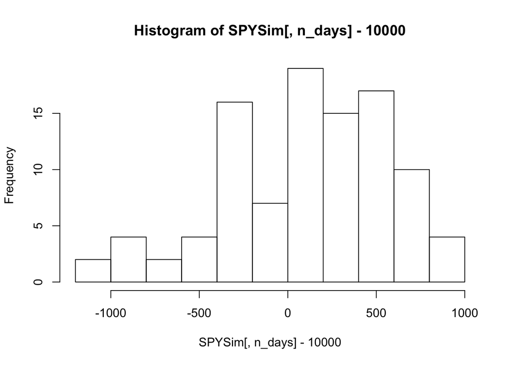

```r
hist(SPYSim[,n_days]- 10000)
```

```r
mean(SPYSim[,n_days])-10000
```

```
## [1] 99.2077
```

```r
(mean(SPYSim[,n_days])-10000)/10000*100
```

```
## [1] 0.992077
```

- The average return is 10,099.21 for a $10,000 investment or.9921%

### Value at Risk

```r
quantile(SPYSim[,n_days], 0.05) - 10000
```

```
##        5%
## -814.9298
```

- The five percent value at risk is -814.92 dollars.

```r
sd((SPYSim[,n_days]) - 10000)
```

```
## [1] 466.8553
```

- The standard deviation is $466.86

## EEM

```r
EEMSim = foreach(i=1:100, .combine='rbind') %do% {
  totalwealth = 10000
  weights = c(0.0, 0.0, 0.0, 1.0, 0.0)
  holdings = weights * totalwealth
  wealthtracker = rep(0, n_days) # Set up a placeholder to track total wealth
  for(today in 1:n_days) {
    return.today = resample(Assetreturns, 1, orig.ids=FALSE)
    holdings = holdings + holdings*return.today
    totalwealth = sum(holdings)
    wealthtracker[today] = totalwealth
  }
  wealthtracker
}
head(EEMSim)
```

```
##               [,1]      [,2]      [,3]      [,4]      [,5]      [,6]
## result.1 10044.560  9878.619  9967.383  9788.697  9721.430  9551.428
## result.2 10059.467 10094.527 10068.431 10041.923 10112.367  9899.173
## result.3  9891.680 10016.800  9430.520  9609.413  9806.963  9602.958
## result.4  9909.638  9899.183 10028.041 10137.803 10331.503  9964.530
## result.5 10088.058 10122.170 10241.651 10214.261 10375.266 10402.011
## result.6 10066.031 10027.436 10158.609 10085.113 10001.369  9924.175
##               [,7]      [,8]      [,9]     [,10]     [,11]     [,12]
## result.1  9494.234  9438.993  9519.970  9537.004  9528.426  9476.429
## result.2  9739.942  9614.855  9511.205  9635.634  9775.614  9921.835
## result.3  9457.392  9658.668  9581.452  9519.988  9608.294  9733.994
## result.4  9949.782  9979.553 10141.840 10119.145  9807.423  9885.160
## result.5 10420.821 10485.994 10608.680 10641.009 10723.441 10707.271
## result.6  9711.319  9826.040  9685.741  9777.829  9811.923  9593.935
##              [,13]     [,14]     [,15]     [,16]     [,17]     [,18]
## result.1  9782.966  9761.621  9395.561  9227.126  9282.117  9235.813
## result.2  9855.036  9454.896  9437.098  9411.723  9431.413  9451.857
## result.3 10271.316 10321.177 10231.510 10184.587 10028.765 10149.514
## result.4  9749.843  9749.843  9635.015  9470.175  9624.367  9528.538
## result.5 10565.561 10867.569 10742.904 10832.644 10972.437 10577.726
## result.6  9651.759  9532.574  9680.239  9780.100  9748.102  9783.801
##              [,19]     [,20]
## result.1  9285.724  9236.704
## result.2  9507.920  9372.864
## result.3  9784.406  9770.161
## result.4  9438.288  9100.737
## result.5 10282.000 10313.915
## result.6  9791.331  9766.018
```

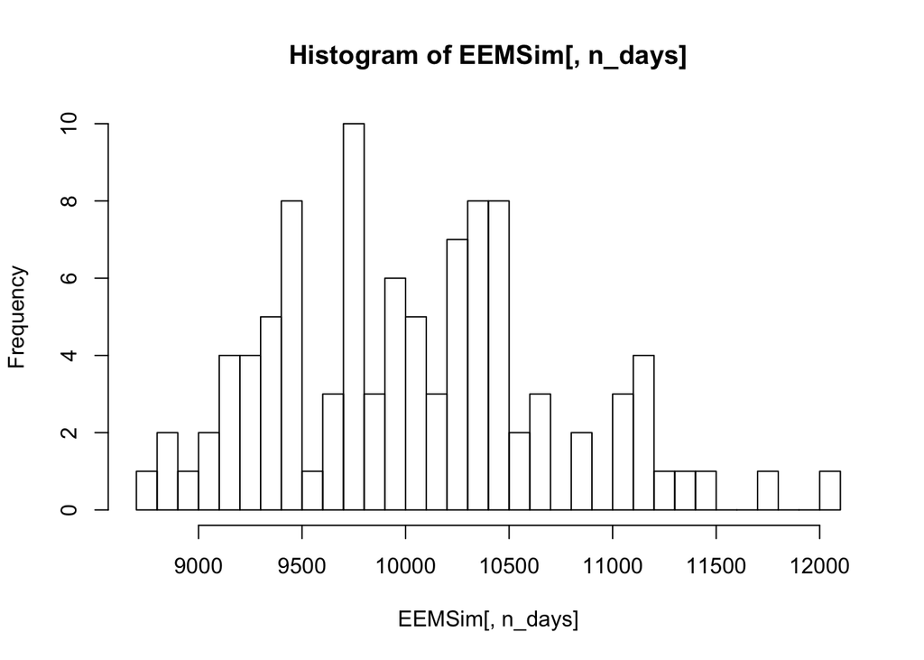

```r
hist(EEMSim[,n_days],25)
```

### Checking for profits

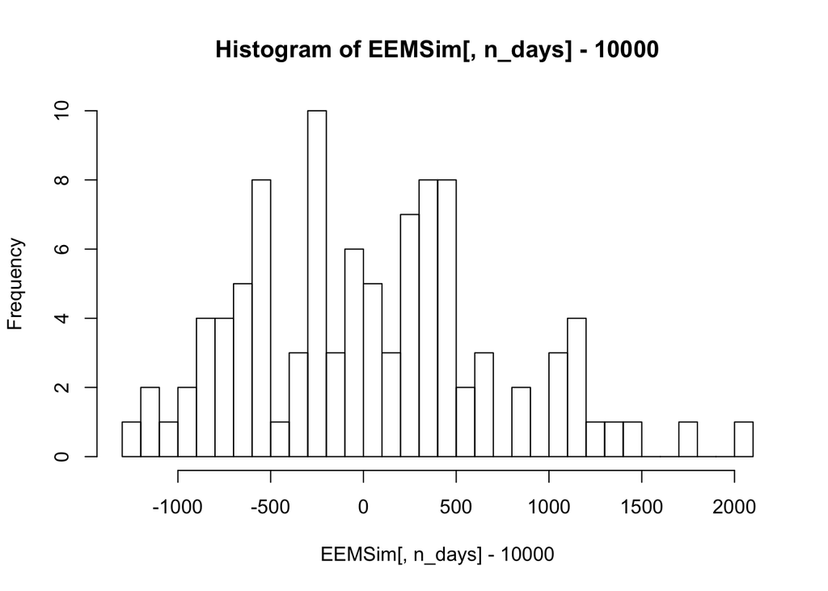

```r
hist(EEMSim[,n_days]- 10000,25)
```

```r
mean(EEMSim[,n_days])-10000
```

```
## [1] 39.58961
```

```r
(mean(EEMSim[,n_days])-10000)/10000*100
```

```
## [1] 0.3958961
```

-The average return is $10,039.59 for a $10,000 investment or 0.3959%.

### Value at Risk

```r
quantile(EEMSim[,n_days], 0.05) - 10000
```

```
##        5%
## -935.1124
```

-The five percent value at risk is -935.11 dollars.

```r
sd(EEMSim[,n_days])
```

```
## [1] 678.1143
```

- The standard deviation is $678.11

## VNQ

```r
VNQSim = foreach(i=1:100, .combine='rbind') %do% {
  totalwealth = 10000
  weights = c(0, 0.0, 0.0, 0.0, 1.0)
  holdings = weights * totalwealth
  wealthtracker = rep(0, n_days) # Set up a placeholder to track total wealth
  for(today in 1:n_days) {
    return.today = resample(Assetreturns, 1, orig.ids=FALSE)
    holdings = holdings + holdings*return.today
    totalwealth = sum(holdings)
    wealthtracker[today] = totalwealth
  }
  wealthtracker
}

head(VNQSim)
```

```
##               [,1]      [,2]      [,3]      [,4]      [,5]      [,6]
## result.1  9777.729  9797.316  9732.100  9741.379  9700.748  9745.811
## result.2  9867.910  9927.449 10026.192 10123.686 10096.314 10106.680
## result.3  9753.296  9835.425 10058.465  9979.002  9985.901 10060.809
## result.4 10078.714 10098.360 10100.015  9860.068 10077.126  9773.349
## result.5  9914.406  9819.633  9909.292  9841.441  9971.265 10029.609
## result.6  9982.341 10087.588 10215.771 10028.109  9955.632  9935.632
##               [,7]      [,8]      [,9]     [,10]     [,11]     [,12]
## result.1  9499.540  9548.131  9417.191  9384.781  9399.261  9240.686
## result.2 10067.470 10090.036 10119.182 10137.831 10164.553 10140.633
## result.3 10146.132 10267.233 10378.577 10450.112 10584.551 10605.726
## result.4  9721.932  9646.567  9647.930  9793.581  9742.108  9716.080
## result.5  9814.120 10030.166 10031.674 10019.815  9899.797 10114.710
## result.6 10021.690 10046.290 10027.948 10150.816  9932.273  9986.821
##              [,13]     [,14]     [,15]     [,16]     [,17]     [,18]
## result.1  9177.939  9061.799  9080.359  8712.236  8951.190  8989.940
## result.2 10126.733 10155.984 10146.950 10129.422 10149.156 10189.058
## result.3 10674.419 10755.090 10873.440 10801.596 10821.504 10838.802
## result.4  9742.015  9732.013  9694.256  9597.045  9791.066  9816.842
## result.5 10079.899 10179.555 10197.043 10329.633 10485.575 10697.559
## result.6  9913.982  9906.187  9926.710  9441.725  9437.922  9573.589
##              [,19]     [,20]
## result.1  8995.166  9082.111
## result.2 10162.261 10149.323
## result.3 10600.006 10528.028
## result.4 10054.231 10116.318
## result.5 10607.561 10449.906
## result.6  9640.262  9793.688
```

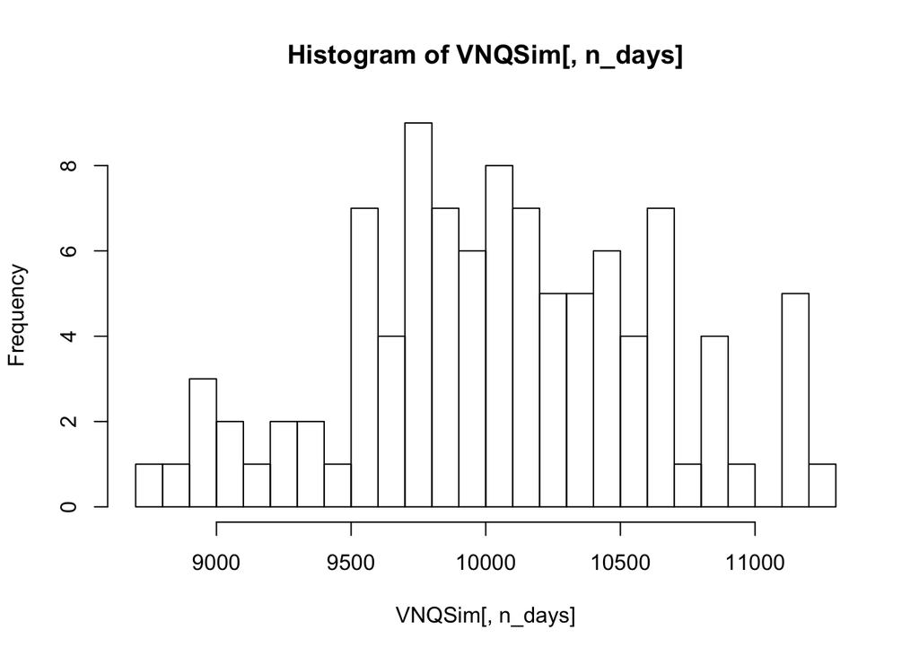

```r
hist(VNQSim[,n_days],20)
```

### Checking for profits

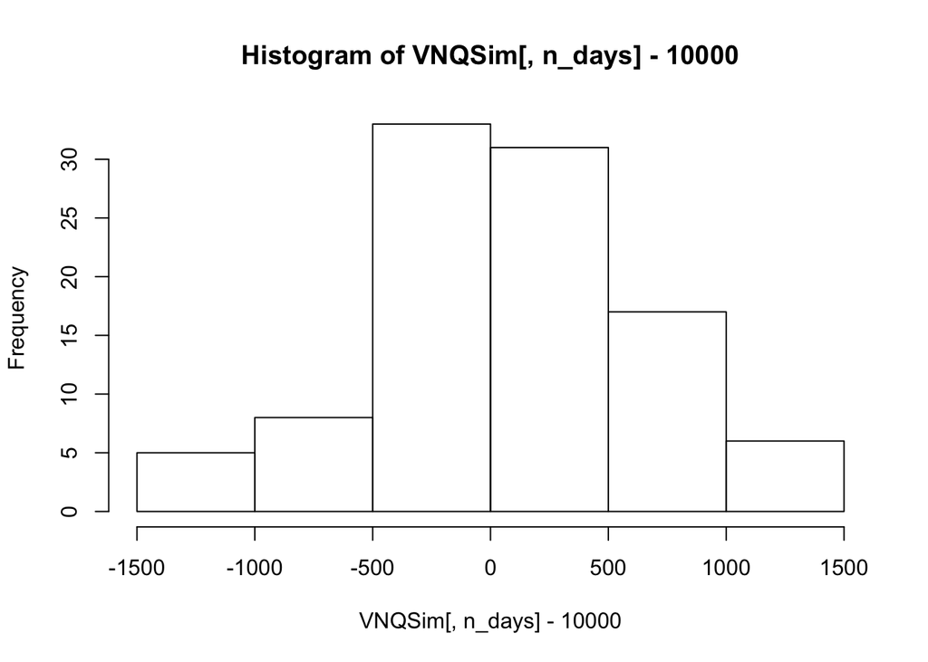

```r
hist(VNQSim[,n_days]- 10000)
```

```r
mean(VNQSim[,n_days])-10000
```

```
## [1] 60.35997
```

```r
(mean(VNQSim[,n_days])-10000)/10000*100
```

```
## [1] 0.6035997
```

```r
quantile(VNQSim[,n_days], 0.05) - 10000
```

```
##        5%
## -936.8349
```

-The 5% value at risk is 936.83 dollars.

```r
sd(VNQSim[,n_days])
```

```
## [1] 570.0723
```

-The standard deviation is $570.07

## Even Sim

```r
EvenSim = foreach(i=1:100, .combine='rbind') %do% {
  totalwealth = 10000
  weights = c(0.2, 0.2, 0.2, 0.2, 0.2)
  holdings = weights * totalwealth
  wealthtracker = rep(0, n_days) # Set up a placeholder to track total wealth
  for(today in 1:n_days) {
    return.today = resample(Assetreturns, 1, orig.ids=FALSE)
    weight= c(0.2,0.2,0.2,0.2,0.2)
    holdings = weight*totalwealth
    holdings = holdings + holdings*return.today
    totalwealth = sum(holdings)
    wealthtracker[today] = totalwealth
  }
  wealthtracker
}
```

### A histogram of the 20th day of the simulations

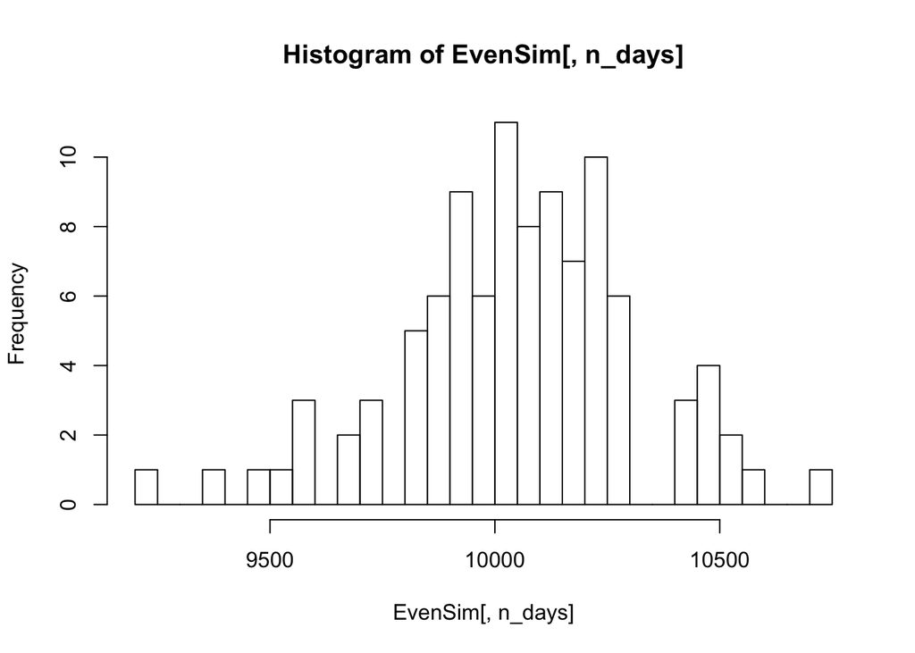

```r
hist(EvenSim[,n_days],25)
```

### Expected result

```r
mean(EvenSim[,n_days])
```

```
## [1] 10047.08
```

### Five percent at risk

```r
quantile(EvenSim[,n_days], 0.05)-10000
```

```
##        5%
## -412.3162
```

- The Five percent value at risk is $412.32

## Weighting the options

- Since the averages are only the mean, they don’t indicate how potentially high an assets’ return might be. So I will look at the max and third quartile of the five to decide what has the top return potential.

```r
quantile(LQDSim[,n_days], 0.75)-10000; max(LQDSim[,n_days])-10000
```

```
##      75%
## 140.9227
```

```
## [1] 445.2068
```

- 75% LQD = < 140.92. Max = 445.21

```r
quantile(TLTSim[,n_days], 0.75)-10000; max(TLTSim[,n_days])-10000
```

```
##      75%
## 365.2941
```

```
## [1] 1450.349
```

-75% TLT = < 365.29 Max = 1,450.35

```r
quantile(SPYSim[,n_days], 0.75)-10000; max(SPYSim[,n_days])-10000
```

```
##      75%
## 431.3039
```

```
## [1] 903.5787
```

-75% SPY = < 431.30 Max = 903.58

```r
quantile(EEMSim[,n_days], 0.75)-10000; max(EEMSim[,n_days])-10000
```

```
##     75%
## 424.818
```

```
## [1] 2003.97
```

-75% EEM = < 424.82 Max = 2,003.97

```r
quantile(VNQSim[,n_days], 0.75)-10000; max(VNQSim[,n_days])-10000
```

```
##      75%
## 480.4857
```

```
## [1] 1235.427
```

-75% VNQ = < 480.49 Max = 1,235.43

## “Aggressive” Portfolio

```r
Option2= foreach(i=1:100, .combine='rbind') %do% {
  totalwealth = 10000
  weights = c(0.0, 0.0, 0.0, 0.5, 0.5)
  holdings = weights * totalwealth
  wealthtracker = rep(0, n_days) # Set up a placeholder to track total wealth
  for(today in 1:n_days) {
    return.today = resample(Assetreturns, 1, orig.ids=FALSE)
    weight = c(.0, .0, 0.0, 0.5, 0.5)
    holdings = weight*totalwealth
    holdings = holdings + holdings*return.today
    totalwealth = sum(holdings)
    wealthtracker[today] = totalwealth
  }
  wealthtracker
}
```

### A histogram of the 20th day of the simulations

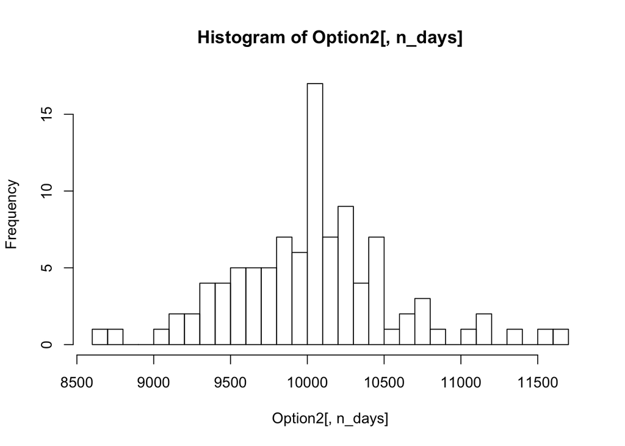

```r
hist(Option2[,n_days],25)
```

### Expected result

```r
mean(Option2[,n_days])
```

```
## [1] 10039.24
```

### Five Percent at risk

```r
quantile(Option2[,n_days], 0.05)-10000
```

```
##        5%
## -745.1911
```

- The Five percent value at risk is $745.19

## Option 3: “Safe” portfolio

```r
Option3= foreach(i=1:100, .combine='rbind') %do% {
  totalwealth = 10000
  weights = c(0.4, 0.4, 0.2, 0.0, 0.0)
  holdings = weights * totalwealth
  wealthtracker = rep(0, n_days) # Set up a placeholder to track total wealth
  for(today in 1:n_days) {
    return.today = resample(Assetreturns, 1, orig.ids=FALSE)
    weight = c(0.4, 0.4, 0.2, 0.0, 0.0)
    holdings = weight*totalwealth
    holdings = holdings + holdings*return.today
    totalwealth = sum(holdings)
    wealthtracker[today] = totalwealth
  }
  wealthtracker
}
```

### A histogram of the 20th day of the simulations

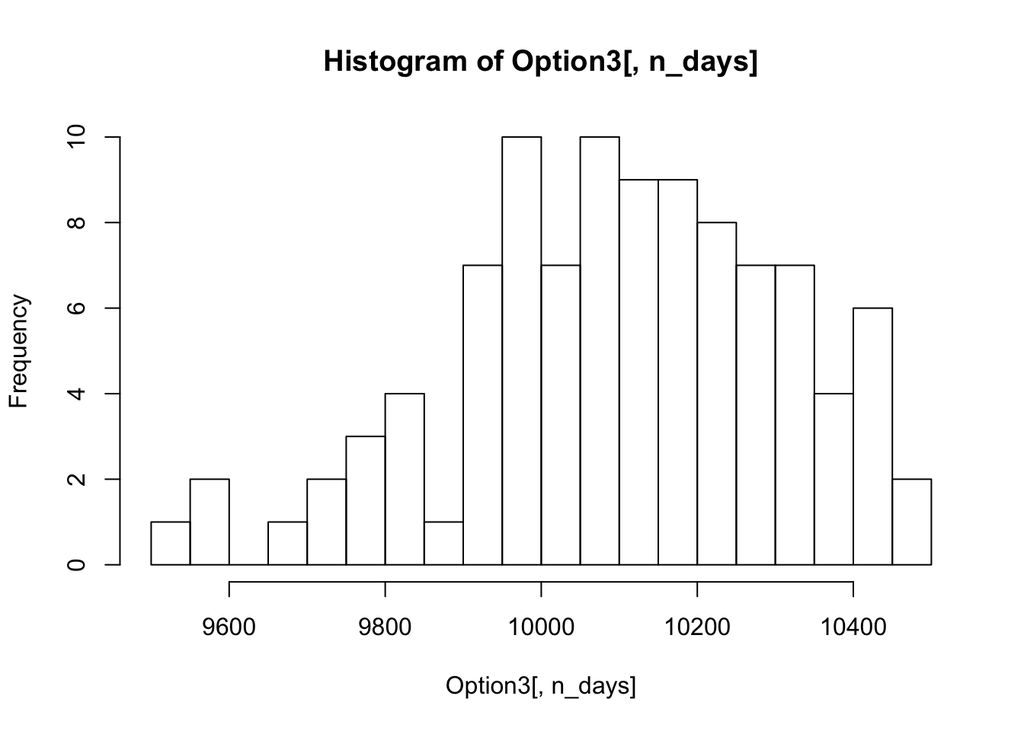

```r
hist(Option3[,n_days],25)
```

### Expected Result

```r
mean(Option3[,n_days])
```

```
## [1] 10101.43
```

-The expected return for the safe porfolio is $10,101.43 for a $10,000 investment over four trading weeks or 1.01%

### Five Percent at risk

```r
quantile(Option3[,n_days], 0.05)-10000
```

```
##        5%
## -253.3825
```

- The Five percent value at risk is $253.38

## Decision Time:

-Option 1: Spreading the investment equally. This option averaged a gain of $47.08 on a $10,000 investment over a four week period with a five percent value at risk of $412.32. -Option 2: The “aggressive” portfolio gained just $39.24 on the $10,000 investment with a five percent value at risk of $745.19. -Option 3: The “safe” portfolio appears to be the best investment, gaining $101.43 on the $10,000 investment while keeping a low five percent value at risk of $253.38.

# Clustering and PCA

## PCA

```r
set.seed(8)
library(ggplot2)
Wine <- read.csv("../data/wine.csv")
attach(Wine)
names(Wine)
```

```
##  [1] "fixed.acidity"        "volatile.acidity"     "citric.acid"
##  [4] "residual.sugar"       "chlorides"            "free.sulfur.dioxide"
##  [7] "total.sulfur.dioxide" "density"              "pH"
## [10] "sulphates"            "alcohol"              "quality"
## [13] "color"
```

```r
WineAttributes= Wine[,1:11]
names(WineAttributes)
```

```
##  [1] "fixed.acidity"        "volatile.acidity"     "citric.acid"
##  [4] "residual.sugar"       "chlorides"            "free.sulfur.dioxide"
##  [7] "total.sulfur.dioxide" "density"              "pH"
## [10] "sulphates"            "alcohol"
```

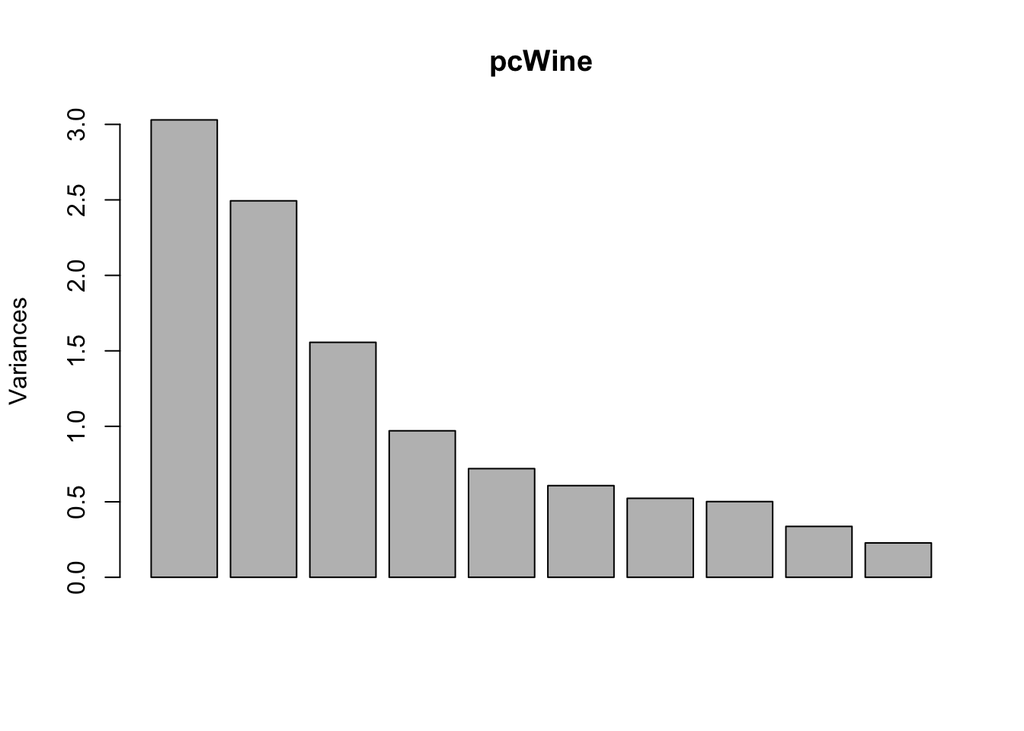

```r
pcWine=prcomp(WineAttributes,scale=TRUE)
plot(pcWine)
```

### PCA plots

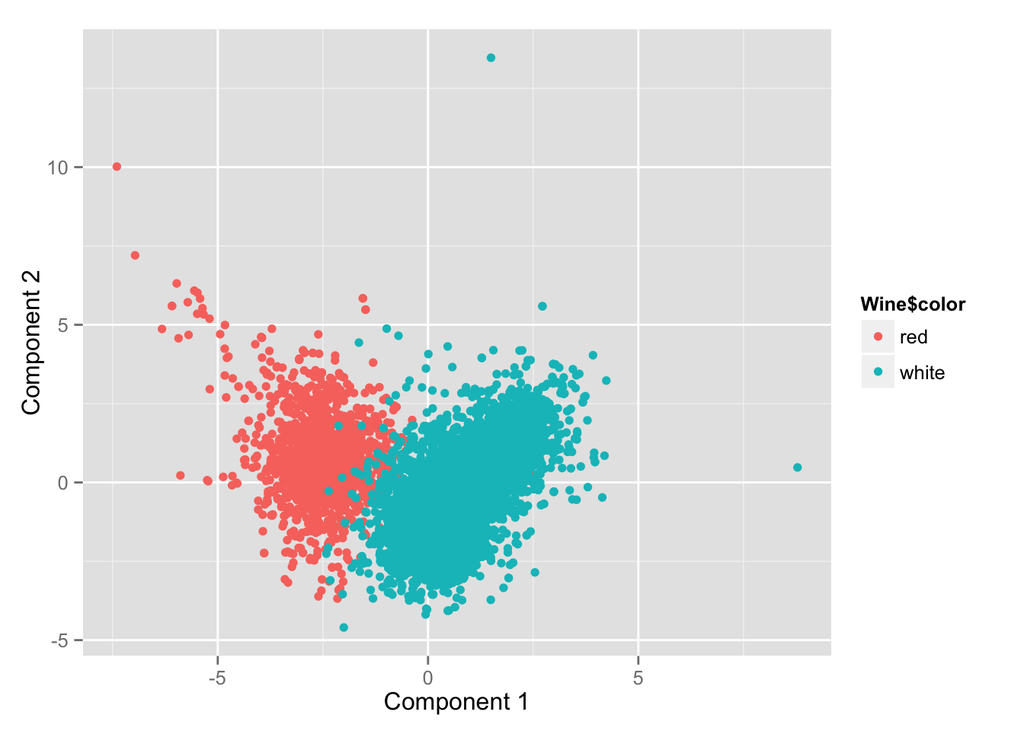

```r
loadings=pcWine$rotation
scores = pcWine$x
qplot(scores[,1], scores[,2], color=Wine$color, xlab='Component 1', ylab='Component 2')
```

```
## stat_bin: binwidth defaulted to range/30. Use 'binwidth = x' to adjust this.
```

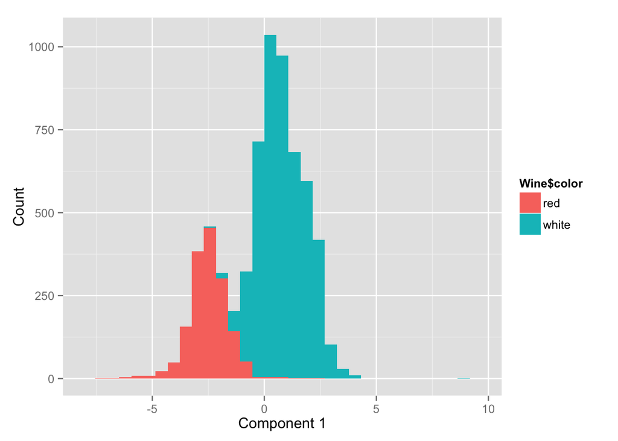

```r
#This plot shows the first two principle components and how well they help differentiate the color of the wine
qplot(scores[,1], fill=Wine$color, xlab='Component 1', ylab='Count')
```

```r
#This plot shows the first principle component and the differentiation of wine colors

# This computes the variance of PCA
pr.var=pcWine$sdev^2
pve=pr.var/sum(pr.var)
pve
```

```
##  [1] 0.275442604 0.226711457 0.141486087 0.088232007 0.065443174
##  [6] 0.055210156 0.047559888 0.045591845 0.030638550 0.020699615
## [11] 0.002984618
```

## Clustering

```r
set.seed(12)
wine_scaled <- scale(WineAttributes, center=TRUE, scale=TRUE)
cluster_all <- kmeans(wine_scaled, centers=2, nstart=50)

cluster_all$centers
```

```
##   fixed.acidity volatile.acidity citric.acid residual.sugar  chlorides
## 1     0.8286464        1.1678795  -0.3378091     -0.5903919  0.9216848
## 2    -0.2804833       -0.3953082   0.1143429      0.1998380 -0.3119753
##   free.sulfur.dioxide total.sulfur.dioxide    density         pH
## 1          -0.8316090           -1.1872380  0.6815493  0.5673286
## 2           0.2814861            0.4018607 -0.2306934 -0.1920315
##    sulphates     alcohol
## 1  0.8430523 -0.07569241
## 2 -0.2853595  0.02562065
```

```r
cluster_all$cluster
```

[output not shown]

[output cut: 177 more lines]

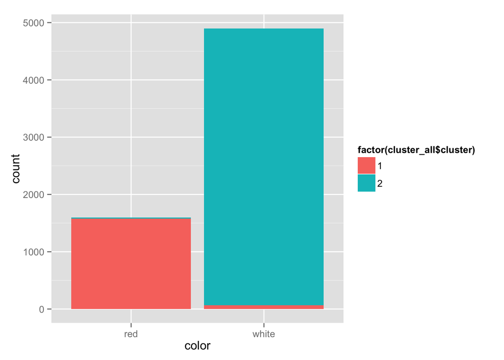

```r
#This plot shows the two cluster by their true colors. This helps understand which cluster projected either red or white wine.
qplot(color,fill=factor(cluster_all$cluster),data= Wine )
```

```r
t1 = table(Wine$color,cluster_all$cluster)
t1
```

```
##
##            1    2
##   red   1575   24
##   white   68 4830
```

-This displays how well each cluster sorted wines by color using the K-means.

```r
p1=prop.table(t1,margin=1)
p1
```

```
##
##                  1          2
##   red   0.98499062 0.01500938
##   white 0.01388322 0.98611678
```

-This table shows the percent of the time each color was sorted into each cluster.

### Results

- Clustering makes more sense in this situation and did a really good job accurately sorting each wine color into the proper cluster( over 98% accuracy). PCA takes a lot of components to explain an equal amount of variance, but that does not really reduct the dimentions.
- Clustering works because it is apparent that there is a difference in red and white wines that is very noticable by K-means. All the characteristics of the two wine types help create two distinct clusters of wine types with nearly 99% accuracy.

## K-means to determine quality of the wines.

```r
set.seed(8)
cluster_alled <- kmeans(wine_scaled,center=10,nstart=500)
cluster_alled$centers
```

```
##    fixed.acidity volatile.acidity citric.acid residual.sugar  chlorides
## 1     0.94594853       1.11685863  1.53479719     -0.7263299  9.8086634
## 2     0.84760441       0.38724744  0.37841367     -0.5942116  0.6360159
## 3    -0.31686399      -0.35443144  0.12975150      0.6706805 -0.2418398
## 4    -0.08178117      -0.37829145  0.40887016      1.8816527 -0.1766247
## 5    -0.19482661       0.06359687  0.91400552     -0.2118164  3.2688813
## 6    -0.59673315      -0.25075473 -0.03485977     -0.4635114 -0.5990193
## 7     0.22198644      -0.46627989  0.20638996     -0.2996376 -0.3997539
## 8     0.06542238       1.85325197 -1.43248998     -0.6297022  0.6925410
## 9    -0.63556511      -0.53798176 -0.19557592     -0.3951413 -0.3258710
## 10    3.11459180       0.54130904  1.37406811     -0.5318015  0.8946525
##    free.sulfur.dioxide total.sulfur.dioxide     density          pH
## 1          -0.87234796          -1.11672865  0.79480696 -0.95727465
## 2          -0.75311981          -1.09361947  0.60857748  0.48396229
## 3           1.35311201           1.21299950  0.35333274 -0.18330482
```

[output cut: 18 more lines]

```r
cluster_alled$cluster
```

[output not shown]

[output cut: 268 more lines]

```
## stat_bin: binwidth defaulted to range/30. Use 'binwidth = x' to adjust this.
```

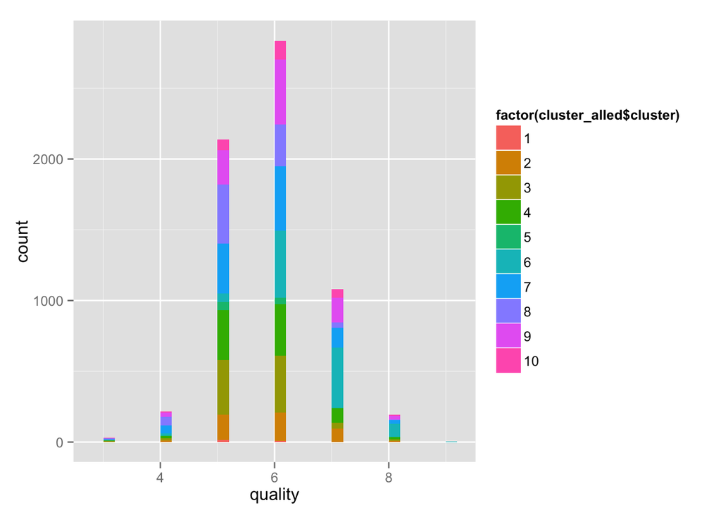

```r
#This plot shows the 10 clusters colored by expected quality score plotted on their actual score.
qplot(quality,fill=factor(cluster_alled$cluster),data= Wine )
```

-KMeans does not accurately determine the quality of the wines. This may be because it does not take color of the wines into account and there may be different factors that determine the quality of white or red wine.

# Market Segmentation

```r
set.seed(2)
Tweet <- read.csv("../data/social_marketing.csv",header=TRUE)
attach(Tweet)
names(Tweet)
```

```
##  [1] "X"                "chatter"          "current_events"
##  [4] "travel"           "photo_sharing"    "uncategorized"
##  [7] "tv_film"          "sports_fandom"    "politics"
## [10] "food"             "family"           "home_and_garden"
## [13] "music"            "news"             "online_gaming"
## [16] "shopping"         "health_nutrition" "college_uni"
## [19] "sports_playing"   "cooking"          "eco"
## [22] "computers"        "business"         "outdoors"
## [25] "crafts"           "automotive"       "art"
## [28] "religion"         "beauty"           "parenting"
## [31] "dating"           "school"           "personal_fitness"
## [34] "fashion"          "small_business"   "spam"
## [37] "adult"
```

```r
head(Tweet)
```

```
##           X chatter current_events travel photo_sharing uncategorized
## 1 hmjoe4g3k       2              0      2             2             2
## 2 clk1m5w8s       3              3      2             1             1
## 3 jcsovtak3       6              3      4             3             1
## 4 3oeb4hiln       1              5      2             2             0
## 5 fd75x1vgk       5              2      0             6             1
## 6 h6nvj91yp       6              4      2             7             0
##   tv_film sports_fandom politics food family home_and_garden music news
## 1       1             1        0    4      1               2     0    0
## 2       1             4        1    2      2               1     0    0
## 3       5             0        2    1      1               1     1    1
## 4       1             0        1    0      1               0     0    0
## 5       0             0        2    0      1               0     0    0
## 6       1             1        0    2      1               1     1    0
##   online_gaming shopping health_nutrition college_uni sports_playing
```

[output cut: 27 more lines]

```r
TweetCat <- Tweet[,2:37]
TweetCat_scaled=scale(TweetCat, center=TRUE, scale=TRUE)

cluster_tweet <- kmeans(TweetCat_scaled, centers=12,nstart=50)

names(cluster_tweet)
```

```
## [1] "cluster"      "centers"      "totss"        "withinss"
## [5] "tot.withinss" "betweenss"    "size"         "iter"
## [9] "ifault"
```

```r
cluster_tweet$cluster
```

[output not shown]

[output cut: 328 more lines]

- I segemented the audience into 12 clusters.

## Looking at the clusters

```r
cluster_tweet$centers
```

```
##        chatter current_events        travel photo_sharing uncategorized
## 1   1.52024406     0.36324422 -0.2129542433    1.21086727  -0.007945765
## 2  -0.37569996    -0.20361124 -0.2260029751   -0.41882096  -0.189802493
## 3  -0.12986503     0.32837009  0.2206605585   -0.08248677   0.666485746
## 4  -0.02601947    -0.04800717 -0.0003698882   -0.20796724   0.231565487
## 5  -0.07901464     0.06340363 -0.1856604087   -0.21733765  -0.094855674
## 6  -0.07340829     0.18287827 -0.0541697083    1.25557232   0.493616789
## 7   0.07205880     0.27684711  0.2887270321   -0.09071828   0.112598536
## 8  -0.09387821     0.10756975  3.2994961820   -0.11981505  -0.100995044
## 9  -0.15675351     0.09671725 -0.1064742934   -0.08945945  -0.121903358
## 10 -0.10215600    -0.08328074 -0.0346184343   -0.01497161  -0.051595416
## 11  1.00856669     0.07214073 -0.0497913578   -0.01741264   0.764867872
## 12 -0.18158817    -0.02882734 -0.1620733123   -0.12264894   0.126336651
##         tv_film sports_fandom    politics        food      family
## 1  -0.137695131    -0.1977609 -0.13610970 -0.31472526 -0.03450647
```

[output cut: 89 more lines]

- Each value is scaled to show how much a group tweets about a given topic in terms of standard deviations of the population.
- 1. Appears to be filled with chatter as well as photo_sharing and shopping
- 2. Is not a particularly useful segment as the values are mostly in the negatives.
- 3. Focuses on arts and crafts as well as small business. Perhaps these are people who create and sell their own art for a living?
- 4. Tweets heavily about adult content.
- 5. Tweets mostly about the news and cars as well as some politics.
- 6. Tweets about fashion,cooking,beauty and photo_sharing. This is likely a predominantly female cluster, and due to the photo sharing I imagine probably girls in their late teens to 20’s.
- 7. Tweet primarily spam( 12.42 standard deviation), so these are likely the spambots.
- 8. Tweets about computers, travel and politics.
- 9. Tweets about watching sports, food, family, religion and school. Sounds like a sports writers demographic (besides school), where some tweet bible verses in the morning then anything else about their day. Often a lot of times that involves sports more than the rest of the population but not always.
- 10. Tweet about colleges and playing sports. Perhaps these are the collegiate athletes?
- 11. Tweet about school, business and fashion.
- 12. Finally we have a group that tweets about the outdoors, personal fitness and fitness and health. This cluster likely frequents the gym and goes on plenty of hikes/runs.

### Examining the length of each cluster

```r
length(cluster_tweet$cluster)  #There are 7,882 users between the 12 clusters
```

```
## [1] 7882
```

```r
length(which(cluster_tweet$cluster==1))
```

```
## [1] 936
```

- Cluster 1 covers 936 users

```r
length(which(cluster_tweet$cluster==2))
```

```
## [1] 3184
```

-Cluster 2 covers 3,184 users

```r
length(which(cluster_tweet$cluster==3))
```

```
## [1] 403
```

- Cluster 3 covers 403 users

```r
length(which(cluster_tweet$cluster==4))
```

```
## [1] 202
```

-Cluster 4 covers 202 users

```r
length(which(cluster_tweet$cluster==5))
```

```
## [1] 417
```

-Cluster 5 covers 417 users

```r
length(which(cluster_tweet$cluster==6))
```

```
## [1] 451
```

-Cluster 6 covers 451 users

```r
length(which(cluster_tweet$cluster==7))
```

```
## [1] 49
```

-Cluster 7 covers 49 users

```r
length(which(cluster_tweet$cluster==8))
```

```
## [1] 341
```

- Cluster 8 covers 341 users

```r
length(which(cluster_tweet$cluster==9))
```

```
## [1] 641
```

-Cluster 9 covers 641 users

```r
length(which(cluster_tweet$cluster==10))
```

```
## [1] 340
```

-Cluster 10 covers 340 users

```r
length(which(cluster_tweet$cluster==11))
```

```
## [1] 191
```

- Cluster 11 covers 191 users

```r
length(which(cluster_tweet$cluster==12))
```

```
## [1] 727
```

-Cluster 12 cover 727 users.

## Key takeaways:

-1. The largest group of users (cluster 2) is the one that is hardest to segment as their scores are predominantly negative. -2. The next largest group is filled with chatter so not very helpful, however the third biggest segment are those who tweet about fitness/ health/ outdoors. -3. People who watch sports make up another sizable proportion of users, followed by the female group.